# Week 05 - Information representation

- Show All Code
- Hide All Code

Network visualisation with `igraph`, `ggraph` and `networkD3`

Welcome to this session of the seminar! In the last weeks you might have seen, that the visualisation of networks is not as easy as it may seem. This is due to the fact, that it is quite difficult to sensefully map 3D Information in a two dimensional space. The content of this chapter is deeply inspired by the materials of Katherine Ognyanova (2024) and (Rawlings et al. 2023).

```r
library(needs)
needs(tidygraph,
      ggraph,
      igraph,
      ggplot2,
      dplyr,
      gganimate,
      networkD3,
      dplyr,
      tidyr,
      tibble,
      stringr,
      gridExtra,
      htmlwidgets,
      intergraph
      )


setwd("C:/Users/ls68bino/Documents/GitHub/SGrehl.github.io/computational-social-sciences")
```

# Visualisation of networks

When we design a network visualization, like almost always we first need to think about the purpose of the visualization. What are the structural features we want to show? What do we want to communicate?

- Do we want to show the network as a whole?
- Do we want to show the network structure?
- Do we want to show the actors and their attributes?
- Do we want to show the edges and their attributes?
- Do we want to show the network dynamics?
- Do we want to show communities or clusters? (next week)
- Do we want to show the network in a geographical context? (We will cover that in geo visualisation)

Most of the time, we will want to show a combination of these features.

When we talk about network visualisation, there are different forms of representation, that we can use. The most common we call network maps, a visualitsation of the nodes and edges in a two-dimensional space. But we can use other forms of representation as well, like

- Good old statistical charts (e.g. bar charts, histograms, boxplots, tables, etc.)
- Arc diagrams
- Heat maps
- etc.

Today we will focus mostly on network maps.

When mapping networks we have different design-elements, that we can use to represent the nodes and edges. The most common are: Color, Position, Size, Shape and Position as well as labels.

# Colors in R

Colors are extremely useful in plotting to differentiate between types of objects or different values of variabes.

Colors can be called by using either named colors, hex or RGB values.

In base R, we can plot by defining point coordinates, symbol shapes, point size and color:

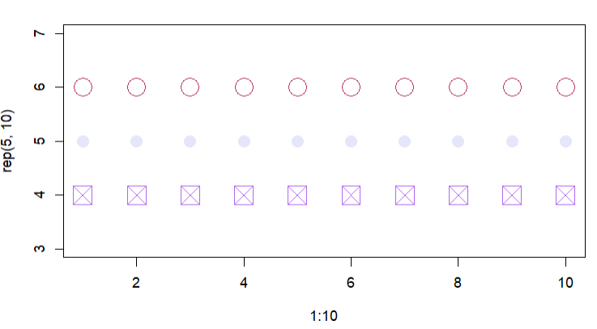

Base plot

```r
plot(x=1:10,
     y=rep(5,10),
     pch=20,
     cex=3,
     col="lavender")

points(x=1:10,
       y=rep(6, 10),
       pch=1,
       cex=3,
       col="#B43757"
)

points(x=1:10,
       y=rep(4, 10),
       pch=7,
       cex=3,
       col=rgb(175, 105, 238, maxColorValue=255)
       )
```

We can also set the the opacity of our colors by using `alpha` in rgb. The alpha value can be set between 0 (transparent) and 1 (opaque).

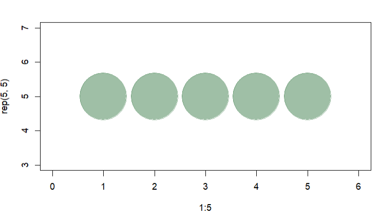

```r
plot(x=1:5,
     y=rep(5,5),
     pch=19,
     cex=12,
     col=rgb(.25, .5, .3, alpha=.5),
     xlim=c(0,6)
     )
```

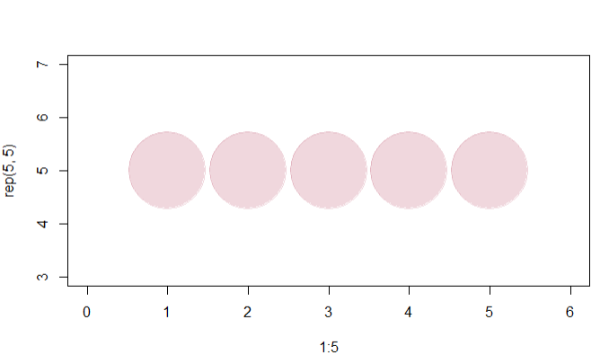

Opacity

```r
col.tr <- grDevices::adjustcolor("#B43757",
                                 alpha=0.2)
plot(x=1:5,
     y=rep(5,5),
     pch=19, cex=12,
     col=col.tr,
     xlim=c(0,6)
     )
```

You can use built-in R colors by using the command `colors()`.

Sometimes we need a number of contrastiing colors. We can use predefined color palettes or the `RColorBrewer` package.

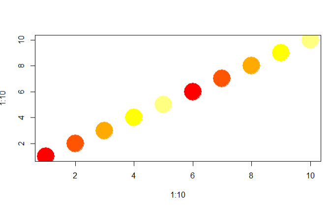

Heat-palette

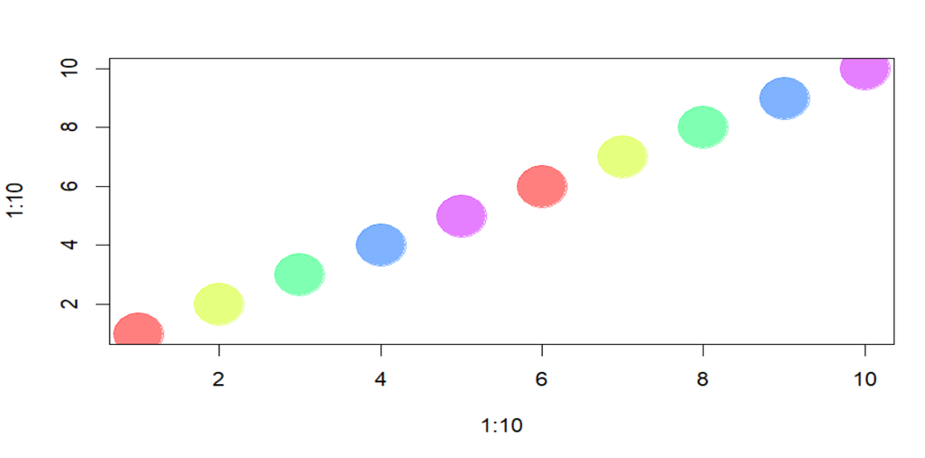

Rainbow-palette

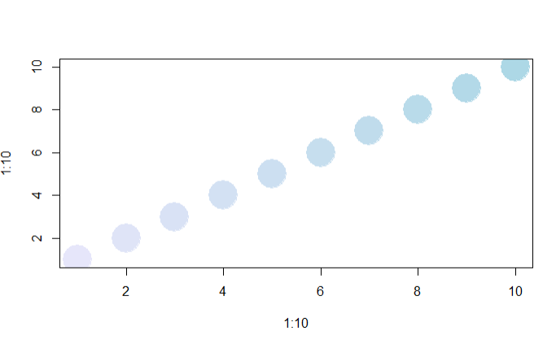

Self-defined palette

```r
par(bg="white")

pal1 <- heat.colors(5,
                    alpha=1
                    ) #  5 colors from the heat palette, opaque

pal2 <- rainbow(5,
                alpha=.5
                )      #  5 colors from the heat palette, transparent

plot(x=1:10,
     y=1:10,
     pch=19,
     cex=5,
     col=pal1
     )

par(mfrow = c(4, 1)
    ) # Set up the plotting area to have 3 rows and 1 column

plot(x=1:10,
     y=1:10,
     pch=19,
     cex=5,
     col=pal2
     )

# Generate our own palette and plot
palf <- colorRampPalette(c("lavender",
                           "lightblue")
                         )
plot(x=1:10,
     y=1:10,
     pch=19,
     cex=5,
     col=palf(10)
     )

palf <- colorRampPalette(c(rgb(1,1,1, .2),
                           rgb(.8,0,0, .7)),
                         alpha=TRUE)

plot(x=10:1,
     y=1:10,
     pch=19,
     cex=5,
     col=palf(10)
     )


library(RColorBrewer)

display.brewer.all() # shows all palettes

par(mfrow = c(1, 1)) # Reset the plotting area to default
```

[output not shown]

# Basic visualisation in ‘igraph’

Remember the `twin-city` network, you created in the last Übungsblatt? We will use it again to day in order to show the different options we have in plotting.

```r
twin_cities <- readRDS("Übungsblätter/Data/twin_cities.rds")



tc_transform <- twin_cities |>
    enframe() |>
    unnest_wider("value") |>
    unnest(c(cities, countries)) |>
    mutate(
        cities = str_replace(cities, "Addis Ababa", "Addis_Abeba"),
        cities = str_replace(cities, "Frankfurt am Main", "Frankfurt_am_Main"),
        cities = str_replace(cities, "Ho Chi Minh City", "Ho_Chi_Minh_Stadt"),
        cities = str_replace(cities, "Kyiv", "Kyjiw"),
        cities = str_replace(cities, "Nanjing", "Nanjing"),
        cities = str_replace(cities, "Kraków", "Krakau")
    )


d1 <- tibble(
  city = c(
    "Addis_Abeba",
    "Birmingham",
    "Bologna",
    "Brünn",
    "Frankfurt_am_Main",
    "Hannover",
    "Herzliya",
    "Ho_Chi_Minh_Stadt",
    "Houston",
    "Krakau",
    "Kyjiw",
    "Lyon",
    "Nanjing",
    "Thessaloniki",
    "Travnik"
  ),
  country = c(
    "Ethiopia",
    "United Kingdom",
    "Italy",
    "Czech Republic",
    "Germany",
    "Germany",
    "Israel",
    "Vietnam",
    "United States",
    "Poland",
    "Ukraine",
    "France",
    "China",
    "Greece",
    "Bosnia and Herzegovina"
  )
) |>
    rename(
        cities = city,
        countries = country
    )


vertices <- tc_transform |>
    select(-name) |>
    rbind(d1) |>
    distinct(cities, .keep_all = T)


edgelist <- tc_transform |>
    select(-countries) |>
    rename(
        from = name,
        to = cities
    )


twin_cities <- graph_from_data_frame(d = edgelist,
                                     directed = FALSE,
                                     vertices = vertices)


twin_cities <- igraph::simplify(twin_cities,
                                       remove.multiple = TRUE,
                                       remove.loops = TRUE)
```

By default, igraph plots the network like this:

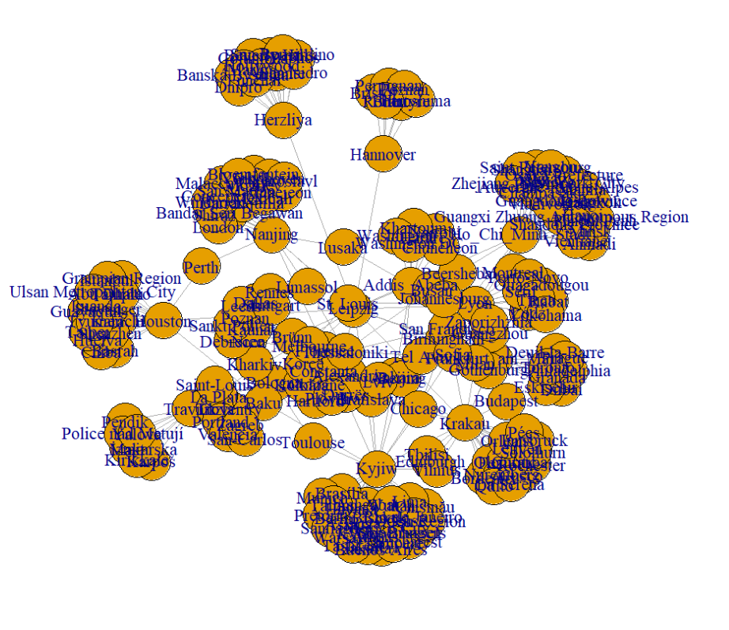

Default plot of the twin city network with `igraph`

As we can clearly see, it is really difficult to identify any nodes or edges, and especially any structure within the network. But already with a few lines of code, we can improve the visualization a lot and make structural metrics more obvious.

## Plotting parameters

Lets have a look at the (most important) different options:

| Parameter | Description |
| --- | --- |
| **NODES** |  |
| vertex.color | Node color |
| vertex.frame.color | Node border color |
| vertex.shape | Node shape options include “none”, “circle”, “square”, “csquare”, “rectangle”, “crectangle”, “vrectangle”, “pie”, “raster”, or “sphere” |
| vertex.size | Size of the node (default is 15) |
| vertex.size2 | Second size of the node (e.g., for a rectangle) |
| vertex.label | Character vector used to label the nodes |
| vertex.label.family | Font family of the label (e.g., “Times”, “Helvetica”) |
| vertex.label.font | Font: 1 plain, 2 bold, 3 italic, 4 bold italic, 5 symbol |
| vertex.label.cex | Font size (multiplication factor, device-dependent) |
| vertex.label.dist | Distance between the label and the vertex |
| vertex.label.degree | Position of the label in relation to the vertex, where 0 is right, “pi” is left, “pi/2” is below, and “-pi/2” is above |
| **EDGES** |  |
| edge.color | Edge color |
| edge.width | Edge width, defaults to 1 |
| edge.arrow.size | Arrow size, defaults to 1 |
| edge.arrow.width | Arrow width, defaults to 1 |
| edge.lty | Line type options: 0 or “blank”, 1 or “solid”, 2 or “dashed”, 3 or “dotted”, 4 or “dotdash”, 5 or “longdash”, 6 or “twodash” |
| edge.label | Character vector used to label edges |
| edge.label.family | Font family of the label (e.g., “Times”, “Helvetica”) |
| edge.label.font | Font: 1 plain, 2 bold, 3 italic, 4 bold italic, 5 symbol |
| edge.label.cex | Font size for edge labels |
| edge.curved | Edge curvature, range 0-1 (FALSE sets it to 0, TRUE to 0.5) |
| arrow.mode | Vector specifying arrow presence: 0 no arrow, 1 back, 2 forward, 3 both |
| **OTHER** |  |
| margin | Empty space margins around the plot, vector with length 4 |
| frame | If TRUE, the plot will be framed |
| main | Adds a title to the plot if set |
| sub | Adds a subtitle to the plot if set |
| asp | Aspect ratio of the plot (y/x), numeric |
| palette | Color palette to use for vertex color |
| rescale | Whether to rescale coordinates to [-1,1], default is TRUE |

There are two ways to define the attributes for a plot. We can either define them directly in the plot prompt or add the information to the igraph-object directly.

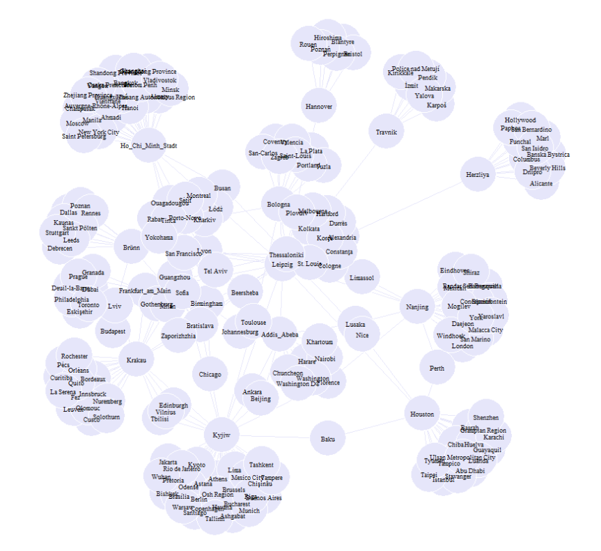

Change of visual parameters

```r
# Option 1:

plot(twin_cities,
     edge.arrow.size=.2,
     edge.color="lavender",
     vertex.color="lavender",
     vertex.frame.color="#ffffff",
     vertex.label.color="black",
     vertex.label.cex = 0.5,
     vertex.cex = 3
     )
```

or:

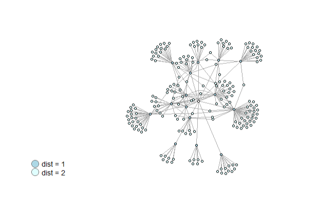

Saving parameters in igraph-objects directly

```r
tc <- twin_cities
leipzig_vertex <- which(V(tc)$name == "Leipzig")  # Find the index of Leipzig

# Calculate shortest path distances from Leipzig to all other nodes
distances <- distances(tc, v = leipzig_vertex)


# Färbe die Knoten basierend auf der Entfernung von Leipzig
V(tc)$color[distances == 1] <- "lightblue"  # Wenn Abstand 1, Farbe "lightblue"
V(tc)$color[distances == 2] <- "lightcyan"  # Wenn Abstand 2, Farbe "lightcyan"


V(tc)$size <- 4

V(tc)$label <- NA

E(tc)$edge.color <- "gray80"


plot(tc)
legend(x="bottomleft",
       c("dist = 1","dist = 2"),
       pch=21,
       col="#777777",
       pt.bg=c("lightblue", "lightcyan"),
       pt.cex=2,
       cex=.8,
       bty="n",
       ncol=1)
```

or we can only plot names (this time for a subset of nodes for visibility)

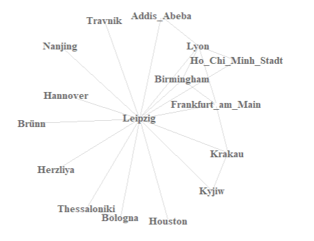

Plot only labels

```r
summary(V(tc)$color)
V(tc)$color[V(tc)$name == "Leipzig"] <- "lightblue"


lightblue_nodes <- V(tc)[which(V(tc)$color == "lightblue")]

V(tc)$label <- V(tc)$name
# Create the subgraph with those nodes
lightblue_subgraph <- induced_subgraph(tc, lightblue_nodes)

# called aus irgendeinem grund das falsche igraph - so gehts
lightblue_subgraph <- igraph::simplify(lightblue_subgraph,
                                       remove.multiple = TRUE,
                                       remove.loops = TRUE)


plot(lightblue_subgraph,
     vertex.shape="none",
     vertex.label=V(lightblue_subgraph)$name,
     vertex.label.font=2,
     vertex.label.color="gray40",
     vertex.label.cex=.7,
     edge.color="gray85"
     )
```

and then again we can overwrite attributes in the plot directly.

## Plotting layouts

The package `igraph` offers a variety of layouts. Depending on the size of the network, we can already see a lot of differences in the plot by changing the layout. The default value is layout_nicely, a smart function that chooses a layouter based on the graph.

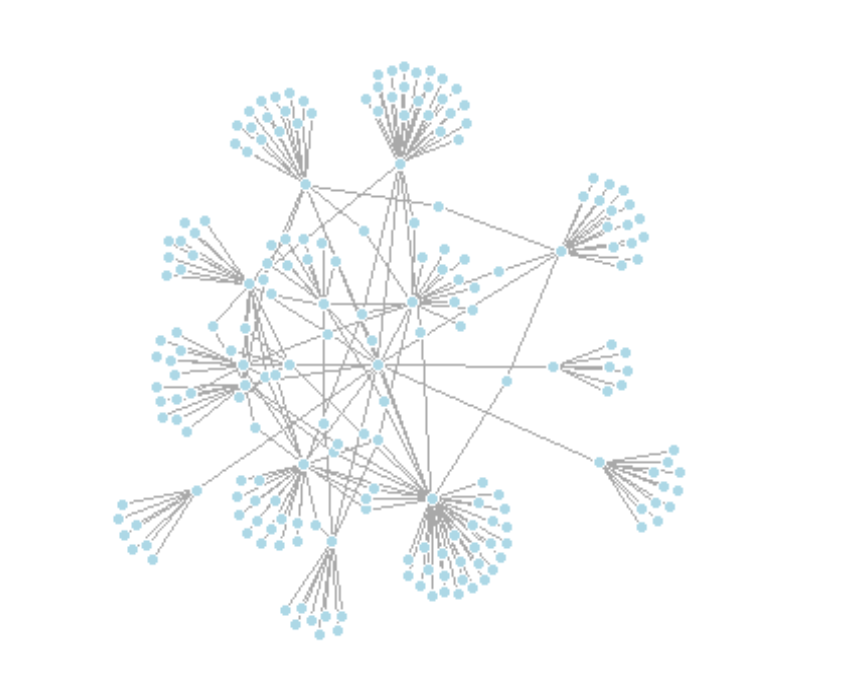

Default layout

```r
V(twin_cities)$size <- 5
V(twin_cities)$frame.color <- "white"
V(twin_cities)$color <- "lightblue"
V(twin_cities)$label <- ""
E(twin_cities)$arrow.mode <- 0

plot(twin_cities)
```

`Igraph` has a lot of built in layouts that are either a function or a numeric matrix, that specify how the vertices will be placed in a plot.

If it is a numeric matrix, then the matrix has to have one line for each vertex, specifying its coordinates. The matrix should have at least two columns, for the x and y coordinates, and it can also have third column, this will be the z coordinate for 3D plots and it is ignored for 2D plots.

If a two column matrix is given for the 3D plotting function rglplot then the third column is assumed to be 1 for each vertex.

```r
plot(twin_cities,
     layout = layout_in_circle)

plot(twin_cities,
     layout=layout_on_sphere)
```

[output not shown]

If layout is a **function**, this function will be called with the graph as the single parameter to determine the actual coordinates. The function should return a matrix with two or three columns. For the 2D plots the third column is ignored.

The **Fruchterman-Reingold** algorithm is a popular **force-directed layout** method. It simulates a physical system where nodes act as repelling particles and edges as attracting springs. This results in a graph where nodes are evenly distributed, with more connected nodes closer together. However, it can be slow and is typically not used for graphs larger than ~1000 vertices.

```r
plot(twin_cities,
     layout=layout_with_fr)
```

With force-directed layouts we can use the `niter` parameter to control the number of iterations to perdorm. The default is set at 500.

```r
plot(twin_cities,
     layout=layout_with_fr(twin_cities,
                           niter=50)
)
```

[figure not shown]

FR-Layout

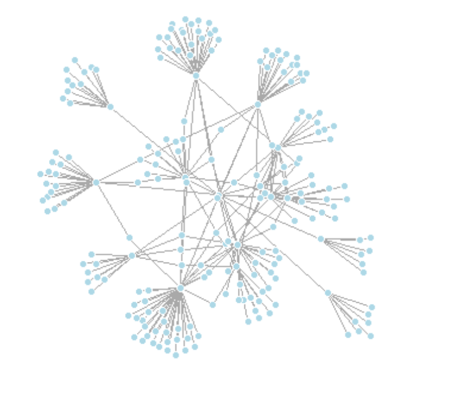

By default, plot coordinates are rescaled to the [-1, 1] interval. To adjust this, set `rescale=FALSE` and manually rescale the plot using a scalar. You can also use `norm_coords` to normalize the plot within custom boundaries for a more compact or spread-out layout.

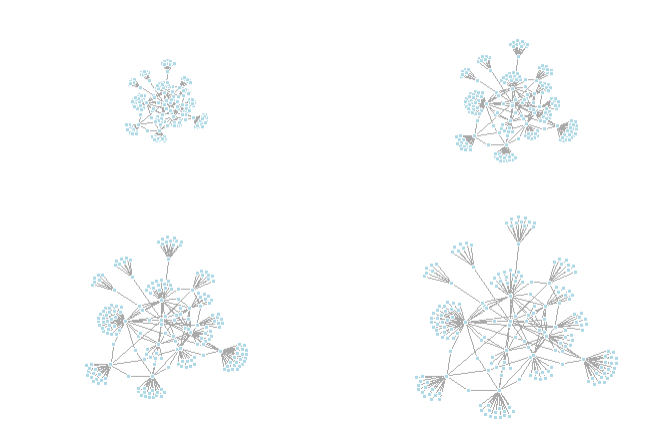

FR with Norm-Coords

```r
l <- layout_with_fr(twin_cities) # save coordinates so layout is not recalculated

# Normalize coordinates to custom boundaries
l <- norm_coords(l, ymin=-1, ymax=1, xmin=-1, xmax=1)

# Set up plot grid
par(mfrow=c(2,2), mar=c(0,0,0,0))

# Plot with varying layouts
plot(twin_cities, rescale=FALSE, layout=l*0.4)
plot(twin_cities, rescale=FALSE, layout=l*0.6)
plot(twin_cities, rescale=FALSE, layout=l*0.8)
plot(twin_cities, rescale=FALSE, layout=l*1.0)
```

The **Kamada-Kawai** algorithm is another force-directed algorithm that minimizes the energy in a spring system.

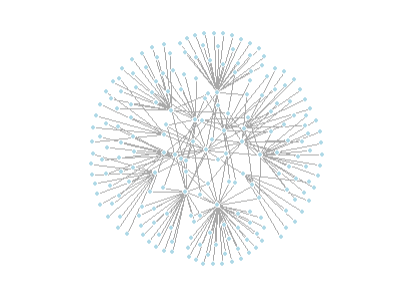

Kamada-Kawaii

```r
plot(twin_cities,
     layout=layout_with_kk)
```

The `graphopt` layout algorithm allows customization of physical simulation parameters that influence the resulting graph layout. You can adjust:

- `charge` — the electric repulsion between nodes (default: `0.001`)
- `mass` — the mass of each node, affecting movement (default: `30`)
- `spring.length` — the ideal edge length (default: `0`)
- `spring.constant` — the stiffness of the springs (default: `1`)

Tweaking these parameters can produce significantly different layouts by changing how nodes repel or attract each other.

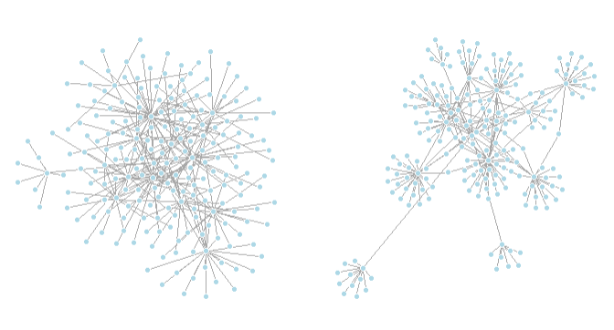

Graphopt with different repulsion

```r
# The charge parameter below changes node repulsion:
l1 <- layout_with_graphopt(twin_cities, charge=0.02)
l2 <- layout_with_graphopt(twin_cities, charge=0.00000001)

par(mfrow=c(1,2), mar=c(1,1,1,1))
plot(twin_cities, layout=l1)
plot(twin_cities, layout=l2)
```

The **MDS (Multidimensional Scaling)** layout positions nodes based on a distance or similarity measure. By default, it uses shortest path distances, placing more similar nodes closer together. You can also supply a custom distance matrix using the `dist` parameter. MDS layouts are useful because node positions reflect actual distances, giving the layout a clear geometric interpretation. However, visual clarity can suffer — nodes may overlap or cluster too tightly.

```r
plot(twin_cities,
     layout = layout_with_mds)
```

[output not shown]

So there are a lot of different ways to plot networks - highlighting different structural properties to the visual analysis (or description).

```r
# Get all layout functions, except the first (which is usually NULL) and bipartite layouts
layouts <- grep("^layout_", ls("package:igraph"), value = TRUE)[-1]
layouts <- layouts[!grepl("bipartite", layouts)]

# Folder to save plots
dir.create("Graphics/layouts", showWarnings = FALSE)

# Plot and save each layout
for (layout in layouts) {
  layout_fun <- get(layout, asNamespace("igraph"))
  l <- layout_fun(twin_cities)

  png(filename = paste0("Graphics/layouts/", layout, ".png"), width = 800, height = 800)
  plot(twin_cities,
       edge.arrow.mode = 0,
       layout = l,
       main = layout)
  dev.off()
}


# Start Quarto block
cat("::: {layout-ncol=4}\n\n")

# Print each image markdown
for (layout in layouts) {
  cat(sprintf('![](Graphics/layouts/%s.png){group="distribution"}\n\n', layout))
}

# End Quarto block
cat(":::\n")
```

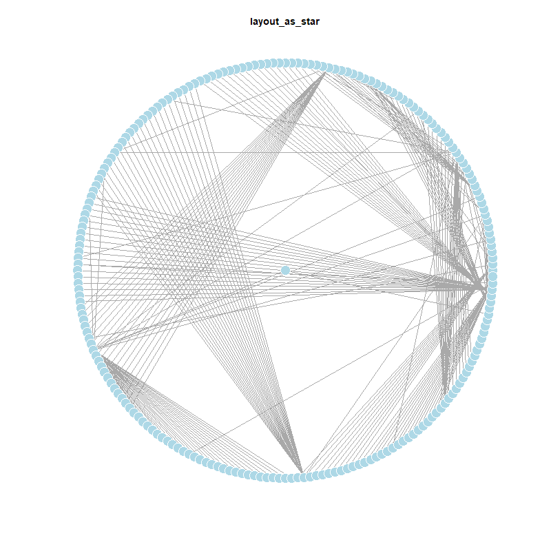

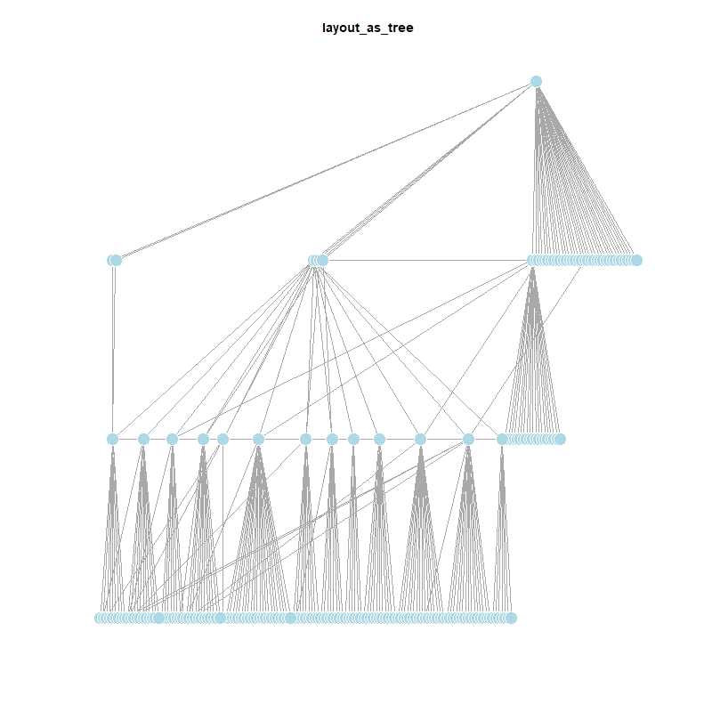

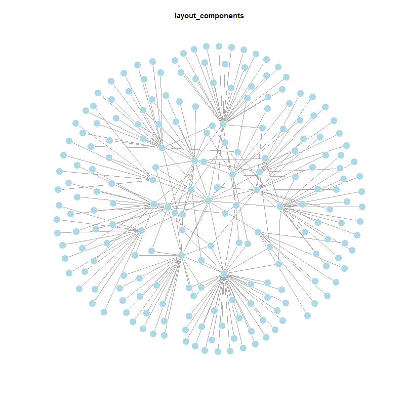

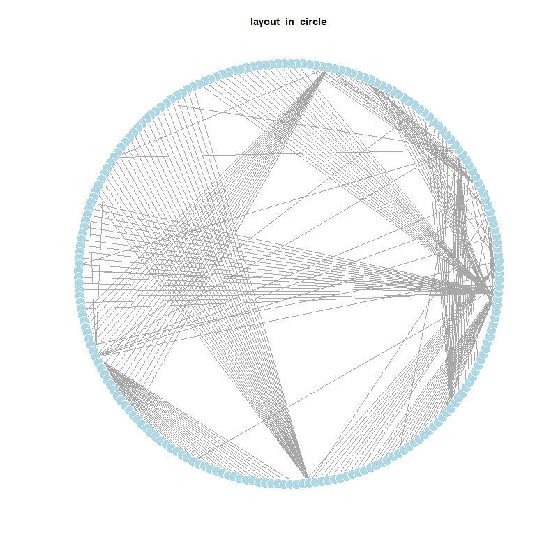

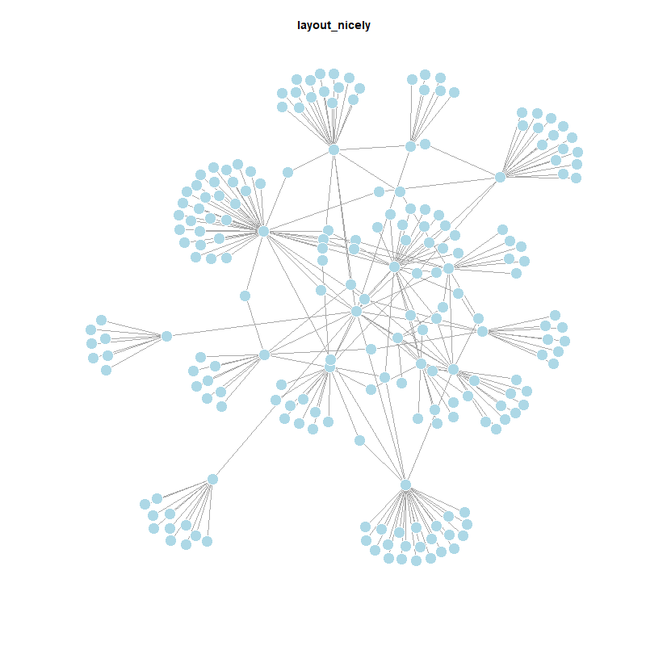

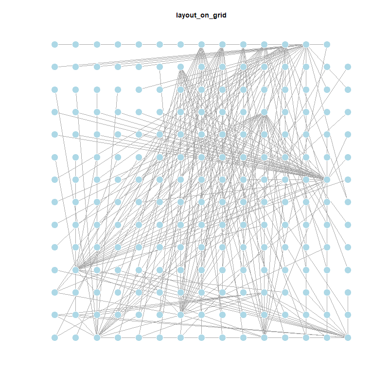

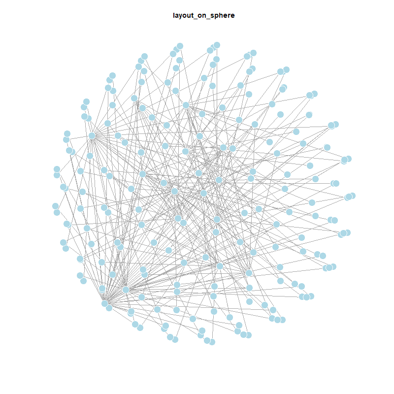

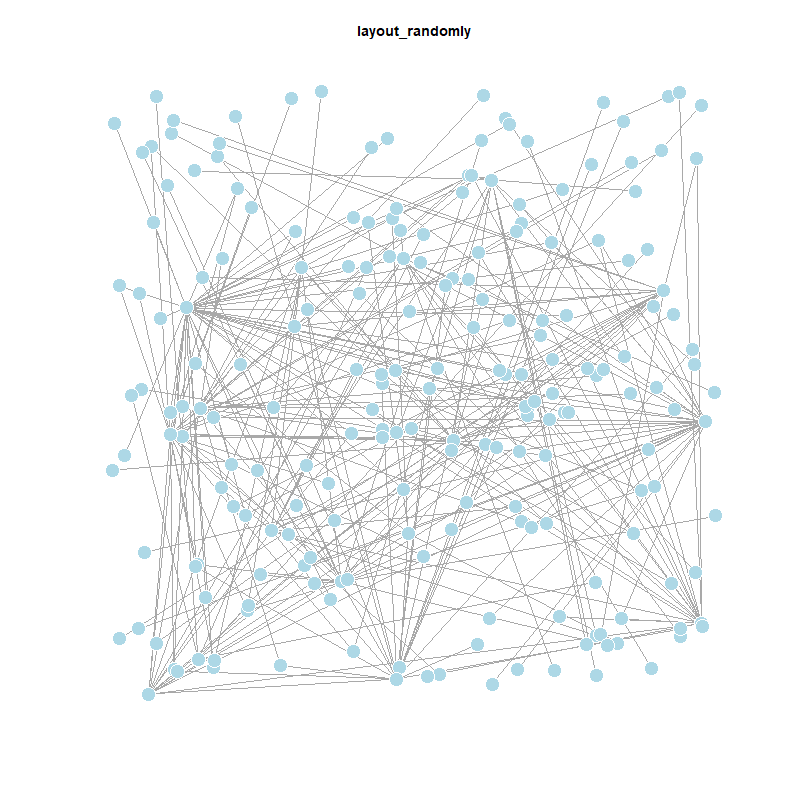

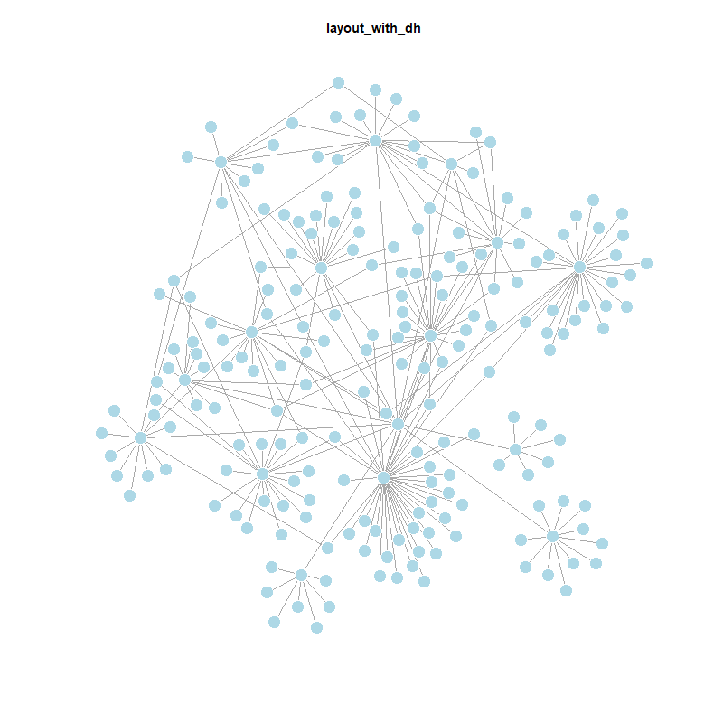

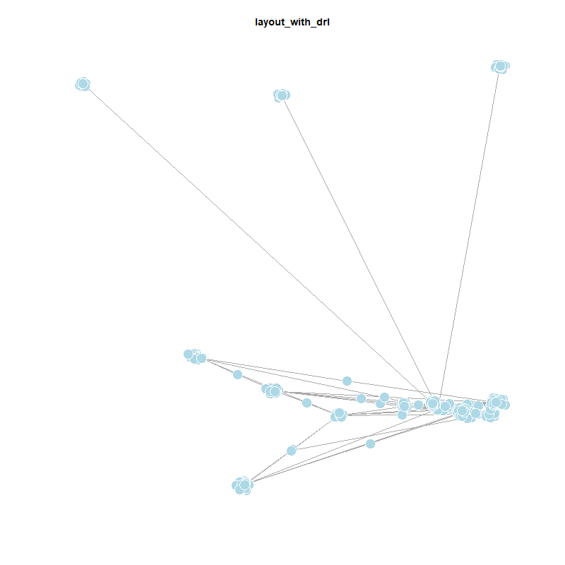

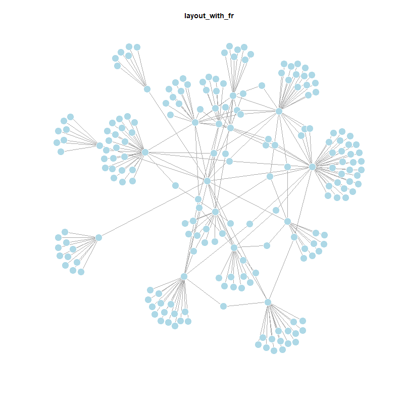

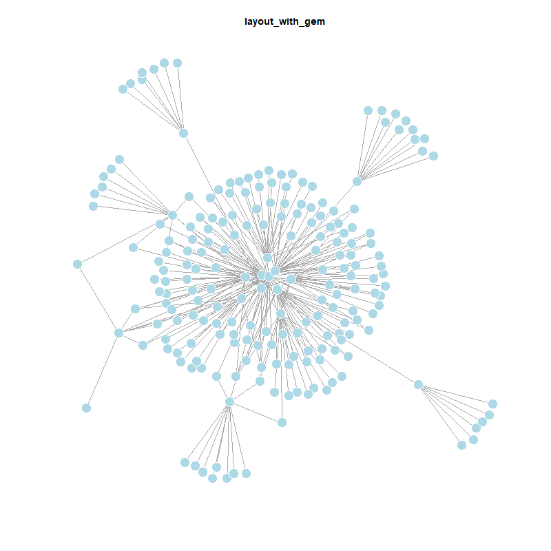

[5 more figures not shown]